# StockPricePrediction

## Stock Price Prediction and Portfolio Optimization

**Objective:** Goal of this project is to develop a machine learning strategy to maximize the gains by implementing reinforcement learning algorithm. First part of the project implements strategy to optimize the portfolio and in the second part Q learning algorithm is implemented to predict the stock movement based on which uy or sell decision is taken.

Technical indicator are identified to generate a rule based manual strategy and then performance of the machine learning strategy is compared with manual rule based strategy with the help of market simulator.

```python
import pandas as pd
import datetime as dt
import matplotlib.pyplot as plt
import numpy as np
from util import get_data, create_df_benchmark, compute_daily_returns, compute_sharpe_ratio, create_df_trades
from marketsim import compute_portvals_single_symbol
from indicators import get_sma_indicator, get_bollinger_bands, get_momentum
from QLearner import QLearner
from strategy import StrategyLearner
import warnings
warnings.filterwarnings('ignore')
import os
import scipy.optimize as spo
```

### 1 Portfolio Optimization

#### 1.1 Dataset

For each stock typically stock data is available in CSV format with columns -

Date, Open, High, Low, Close, Volume, Adj Close

Note that Close column is the actual price that was reported at the exchange when the stock closed for that day and Adjusted Close is the adjusted price due to events such as stock splits and dividend payments etc. We use *pandas dataframe* in order to process this stock data in python.

Pandas functions **df.dropna()** is used to remove rows with NaN values and **df.dropna(subset=’COLNAME’)** is used to remove rows with NaN values in specified column

We also use **df.join** to combine data from two stocks into a single dataframe. **df.join(otherdf, how=’inner’)** executes the inner join, only includes data where both exist in df and other df. It also eliminates all the bad dates when stock market is closed.

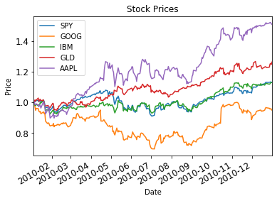

```python
 # Define a date range
start_date = '2010-01-01'
end_date = '2010-12-31'
dates = pd.date_range(start_date, end_date)

# Choose stock symbols to read
symbols = ['GOOG', 'IBM', 'GLD', 'AAPL']

# Get stock data
"""Read stock data (adjusted close) for given symbols from CSV files."""
df = pd.DataFrame(index=dates)
 # add SPY for reference, if absent
if 'SPY' not in symbols:
    symbols = ['SPY'] + symbols

for symbol in symbols:
    df_temp = pd.read_csv(os.path.join("../Data/", "{}.csv".format(str(symbol))), index_col='Date',
            parse_dates=True, usecols=['Date', 'Adj Close'], na_values=['nan'])
    df_temp = df_temp.rename(columns={'Adj Close': symbol})
    df = df.join(df_temp)
    if symbol == 'SPY':  # drop dates SPY did not trade
        df = df.dropna(subset=["SPY"])

# Normalize the stock data
df = df/df.iloc[0,:]

# Slice and plot
"""Plot stock prices with a custom title and meaningful axis labels."""
ax = df.plot(title="Stock Prices", fontsize=12)
ax.set_xlabel("Date")
ax.set_ylabel("Price")
plt.show()
```

#### 1.1 Statistical Analysis of Time Series

**Rolling Statistics:** A Bollinger Band® is a technical analysis tool defined by a set of lines plotted two standard deviations (positively and negatively) away from a simple moving average (SMA) of the security's price, but can be adjusted to user preferences. Bollinger Bands® were developed and copyrighted by famous technical trader John Bollinger.

**Daily Return:** Daily return is the profit/loss made by the stock compared to the previous day.

**Cumulative Return:** While daily returns are useful, it doesn't give immediate insight into the gains he had made till date, especially if the stock is very volatile. Cumulative return is computed relative to the day investment is made. If cumulative return is above one, you are making profits else you are in loss.

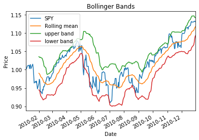

[figure not shown]

```python
# Compute Bollinger Bands for SPY
# 1. Compute rolling mean
rm_SPY = df['SPY'].rolling(window=20).mean()

# 2. Compute rolling standard deviation
rstd_SPY = df['SPY'].rolling(window=20).std()

# 3. Compute upper and lower bands
upper_band = rm_SPY + rstd_SPY*2
lower_band = rm_SPY - rstd_SPY*2

# Plot raw SPY values, rolling mean and Bollinger Bands
ax = df['SPY'].plot(title="Bollinger Bands", label='SPY')
rm_SPY.plot(label='Rolling mean', ax=ax)
upper_band.plot(label='upper band', ax=ax)
lower_band.plot(label='lower band', ax=ax)

# Add axis labels and legend
ax.set_xlabel("Date")
ax.set_ylabel("Price")
ax.legend(loc='upper left')
plt.show()

# Compute and plot daily returns for SPY and XOM
daily_returns = df.pct_change()
daily_returns.iloc[0,:] = 0
ax = df['SPY'].plot(title="Daily returns", fontsize=12)
ax.set_xlabel("Date")
ax.set_ylabel("Price")
plt.show()
```

#### 1.2 Processing Incomplete Data

Stock data is an amalgamation from many sources. Stock data may be incomplete because - **A stock may trade at different prices in NY Stock Exchange, another price as NASDAQ** There is no single price for any stock **Not all stock trade every day** Stocks come into existence and there’s values for them and before there was no data **Sometimes stocks go out of existence and suddenly they quit existing and there’s no data for them going forward** Sometimes stocks will be trading, data will be missing, then it starts trading again

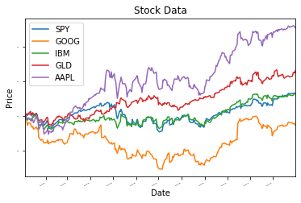

```python
"""Fill missing values in data frame, in place."""
df.fillna(method='ffill', inplace=True)
df.fillna(method='bfill', inplace=True)

"""Plot stock data with appropriate axis labels."""
ax = df.plot(title="Stock Data", fontsize=2)
ax.set_xlabel("Date")
ax.set_ylabel("Price")
plt.show()
```

#### 1.3 Histogram of Daily Returns

Kurtosis tells us about the tails of a distribution. If we assume that our histogram is similar to a gaussian Distribution or normal distribution, then the measure of Kurtosis tells us how different our histogram is from that of the traditional distribution.  
**If we measure a positive Kurtosis (fat tails) it means that there are more occurrences out in these tails than there are in the normal distribution.**  
If we measure a negative Kurtosis (skinny tails) it means that there are fewer occurrences out in these tails than there are in the normal distribution

Volatility is measured by the standard deviation of daily returns displayed using Histogram. Volatile stocks have return distributions that are very spread out. By contrast, low volatility stocks have tight distributions, where the daily returns are clustered around the average.

**Scatter Plots:** (the daily returns of that stock with respect to SPY) Beta - how reactive is the stock to the market. If the slope (Beta) is 1 it means that if the market goes up 1%, that stock also goes up 1%. If beta is 2, if the market goes up 1%, the stock goes up 2%. Alpha - That stock on average is performing a little bit better than the S&P500 (SPY) every day if Alpha is positive. If it’s negative it means it’s returned a little less than the market overall.

**The slope (Beta) is not Correlation!** Correlation is how tightly these individual points fit that line. So you could have a shallow slope with a higher correlation, or you can have a steeper slope and the data fitting the line at a higher correlation.

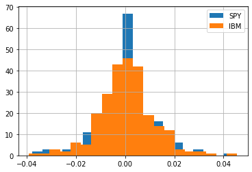

```
beta_IBM = 0.7768113340296214
alpha_IBM = 0.00011502625754503566
beta_GLD = 0.17204065929330128
alpha_GLD = 0.0008868754440200367
```

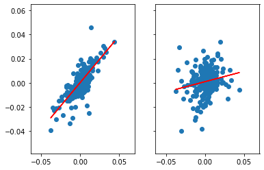

```
           SPY      GOOG       IBM       GLD      AAPL
SPY   1.000000  0.645446  0.781873  0.186382  0.708686
GOOG  0.645446  1.000000  0.491107  0.107257  0.587522
IBM   0.781873  0.491107  1.000000  0.153023  0.606461
GLD   0.186382  0.107257  0.153023  1.000000  0.196158
AAPL  0.708686  0.587522  0.606461  0.196158  1.000000
```

```python
# Plot both histograms on the same plot
daily_returns["SPY"].hist(bins=20, label="SPY")
daily_returns["IBM"].hist(bins=20, label="IBM")
plt.legend(loc="upper right")
plt.show()

# Scatterplot SPY vs. XOM and SPY vs. GLD and the respective best fitting lines
# Two subplots appear side by side
f, (ax1, ax2) = plt.subplots(1, 2, sharey=True)

# The first subplot SPY vs. XOM and its best fitting line
ax1.scatter(daily_returns["SPY"], daily_returns["IBM"])
beta_IBM, alpha_IBM = np.polyfit(daily_returns["SPY"], daily_returns["IBM"], 1)
print ("beta_IBM = {}\nalpha_IBM = {}".format(beta_IBM, alpha_IBM))
ax1.plot(daily_returns["SPY"], beta_IBM*daily_returns["SPY"] + alpha_IBM, "-", color="r")

# The first subplot SPY vs. GLD and its best fitting line
ax2.scatter(daily_returns["SPY"], daily_returns["GLD"])
beta_GLD, alpha_GLD = np.polyfit(daily_returns["SPY"], daily_returns["GLD"], 1)
print ("beta_GLD = {}\nalpha_GLD = {}".format(beta_GLD, alpha_GLD))
ax2.plot(daily_returns["SPY"], beta_GLD*daily_returns["SPY"] + alpha_GLD, "-", color="r")

plt.show()

# Calculate the correlation coefficient
print (daily_returns.corr(method="pearson"))
```

#### 1.4 Portfolio Statistics

To assess the performance of portfolio following statistics are tracked -

- Cumulative return
- Average period return (if sampling frequency == 252 then this is average daily return)
- Standard deviation of daily returns
- Sharpe ratio of the overall portfolio, given daily risk free rate (usually 0), and yearly sampling frequency (usually 252, the no. of trading days in a year)
- Ending value of the portfolio

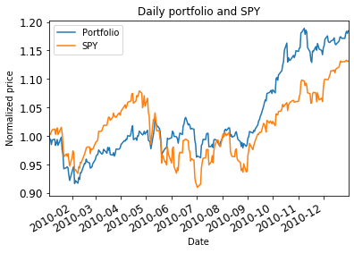

```
Start Date: 2010-01-01
End Date: 2010-12-31
Symbols: ['SPY', 'GOOG', 'IBM', 'GLD', 'AAPL']
Allocations: [0.2, 0.3, 0.4, 0.1]
Sharpe Ratio: 1.2958472523776996
Volatility (stdev of daily returns): 0.008728233367072897
Average Daily Return: 0.0007124918342055423
Cumulative Return: 0.18438903948877128
End value: 1184389.0394887712
```

```python
allocations = [0.2, 0.3, 0.4, 0.1]
start_val = 1000000
risk_free_rate = 0.0
sample_freq = 252

prices = df[['GOOG', 'IBM', 'GLD', 'AAPL']]  # only portfolio symbols
prices_SPY = df["SPY"]  # only SPY, for comparison later

# Get daily portfolio value
# Normalize the prices according to the first day
norm_prices = prices/prices.iloc[0,:]

# Compute prices based on the allocations
alloc_prices = norm_prices * allocations

# Calculate position values
pos_vals = alloc_prices * start_val

# Get daily portfolio value
port_val = pos_vals.sum(axis=1).to_frame()
port_val.columns = ["port_val"]

# Get portfolio statistics (sddr == volatility)
cr = port_val.iloc[-1, 0]/port_val.iloc[0, 0] - 1

#Compute daily returns
daily_returns = port_val.pct_change()
daily_returns.iloc[0,:] = 0
daily_returns = daily_returns[1:]

adr = daily_returns["port_val"].mean()
sddr = daily_returns["port_val"].std()
sr = np.sqrt(sample_freq) * (adr - risk_free_rate) / sddr

# Compare daily portfolio value with SPY using a normalized plot
# Create a temporary dataframe with both the SPY and Portfolio
df_temp = pd.concat([port_val, prices_SPY], keys=["Portfolio", "SPY"], axis=1)
df_temp.columns=["Portfolio", "SPY"]

# Normalize the data
df_portval = df_temp/df_temp.iloc[0,:]

# Plot the normalized data
ax = df_portval.plot(title="Daily portfolio and SPY", fontsize=12)
ax.set_xlabel("Date")
ax.set_ylabel("Normalized price")
plt.show()


ev = port_val.iloc[-1, 0]

# Print statistics
print ("Start Date:", start_date)
print ("End Date:", end_date)
print ("Symbols:", df.columns.values.tolist())
print ("Allocations:", allocations)
print ("Sharpe Ratio:", sr)
print ("Volatility (stdev of daily returns):", sddr)
print ("Average Daily Return:", adr)
print ("Cumulative Return:", cr)
print ("End value:", ev)
```

#### 1.5 Portfolio Optimization

The simplest way to optimize the portfolio is to compare Cumulative return of stocks that maximized return over that time period. The allocation would be 100% to the highest returning stock.

But if you want to optimize for minimum volatility or Sharpe ratio you have to evaluate various combinations of those stocks. In order to use an optimizer that minimizes we need to do the following:

- Provide a function to minimize f(x)
- Provide an initial guess for x
- Call the optimizer
- And we want the optimizer to try different allocations to discover the best set of allocations that optimizes this function
- We want to optimize for Sharpe ratio, but f(x) is not the actual Sharpe ratio value, we want to optimize for -1 * the largest Sharpe ratio because the available optimizer function is minimize
- This will find the best allocation or the best value for x to solve this problem
- x can have multiple dimensions and each of the dimensions is the percentage of funds to allocate to each of those stocks

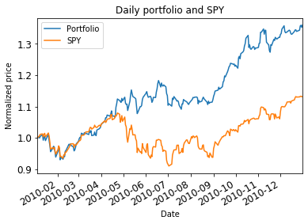

```
Start Date: 2010-01-01
End Date: 2010-12-31
Symbols: ['SPY', 'GOOG', 'IBM', 'GLD', 'AAPL']
Allocations: [0.2, 0.3, 0.4, 0.1]
Sharpe Ratio: 2.0040914011469395
Volatility (stdev of daily returns): 0.010116290276458021
Average Daily Return: 0.0012771400868107372
Cumulative Return: 0.36010376302741953
End value: 1360103.7630274198
```

```python
#Function to optimize
def get_negative_sharpe_ratio(allocs, prices, sv=1000000, rfr=0.0, sf=252):
    # Get daily portfolio value
    # Normalize the prices according to the first day
    norm_prices = prices/prices.iloc[0,:]

    # Compute prices based on the allocations
    alloc_prices = norm_prices * allocs

    # Calculate position values
    pos_vals = alloc_prices * sv

    # Get daily portfolio value
    port_val = pos_vals.sum(axis=1).to_frame()
    port_val.columns = ["port_val"]

    # Get portfolio statistics
    cr = port_val.iloc[-1, 0]/port_val.iloc[0, 0] - 1

    #Compute daily returns
    daily_returns = port_val.pct_change()
    daily_returns.iloc[0,:] = 0
    daily_returns = daily_returns[1:]

    adr = daily_returns["port_val"].mean()
    sddr = daily_returns["port_val"].std()
    sr = np.sqrt(sample_freq) * (adr - risk_free_rate) / sddr
    neg_sr = sr * (-1)

    return neg_sr

bounds = ((0,1),(0,1),(0,1),(0,1))

constraints = ({'type': 'eq', 'fun': lambda x:  np.sum(x)-1.0})

initial_guess = np.ones((len(['GOOG', 'IBM', 'GLD', 'AAPL'])), dtype=np.float32)/(len(['GOOG', 'IBM', 'GLD', 'AAPL']))

result = spo.minimize(get_negative_sharpe_ratio, initial_guess, args=(prices,), method='SLSQP', constraints=constraints, bounds=bounds)
allocs = result.x

norm_prices = prices/prices.iloc[0,:]

# Compute prices based on the allocations
alloc_prices = norm_prices * allocs

# Calculate position values
pos_vals = alloc_prices * start_val

# Get daily portfolio value
port_val = pos_vals.sum(axis=1).to_frame()
port_val.columns = ["port_val"]

cr = port_val.iloc[-1, 0]/port_val.iloc[0, 0] - 1

#Compute daily returns
daily_returns = port_val.pct_change()
daily_returns.iloc[0,:] = 0
daily_returns = daily_returns[1:]

adr = daily_returns["port_val"].mean()
sddr = daily_returns["port_val"].std()
sr = np.sqrt(sample_freq) * (adr - risk_free_rate) / sddr

df_temp = pd.concat([port_val, prices_SPY], keys=["Portfolio", "SPY"], axis=1)
df_temp.columns=["Portfolio", "SPY"]
# Normalize the data
df_portval = df_temp/df_temp.iloc[0,:]

# Plot the normalized data
ax = df_portval.plot(title="Daily portfolio and SPY", fontsize=12)
ax.set_xlabel("Date")
ax.set_ylabel("Normalized price")
plt.show()

ev = port_val.iloc[-1, 0]

# Print statistics
print ("Start Date:", start_date)
print ("End Date:", end_date)
print ("Symbols:", df.columns.values.tolist())
print ("Allocations:", allocations)
print ("Sharpe Ratio:", sr)
print ("Volatility (stdev of daily returns):", sddr)
print ("Average Daily Return:", adr)
print ("Cumulative Return:", cr)
print ("End value:", ev)
```

Choosing a portfolio from among the enormous range of assets now available to an investor would be facilitated if we could locate the return– risk ratio of a particular allocation along a spectrum of possibilities. A comparison between portfolio choices can tell us, for example, whether it is better to select a suboptimal portfolio from a large class of assets or to perform a Markowitz optimal procedure on a subset of the assets. A common criterion for this assessment is the expected return-to-risk tradeoff as measured by the Sharpe ratio.

### 2 Stock Price Prediction

Stock symbol: AAPL  
In-Sampleperiod: January 1, 2007 to December 31 2007.  
Out-Sample: January 1, 2008 to December 31 2008.  
Starting Value: 100,000.  
Allowable positions: 1000 shares long, 1000 shares short, 0 shares.  
There is no limit on leverage.  
Transaction costs: Commission: $9.95, Impact: 0.005.

```python
startdt = dt.datetime(2007,1,1)
enddt = dt.datetime(2007,12,31)
symbols = ['AAPL']
startval = 100000
commission = 9.95
impact = 0.005

# Get Portfolio Benchmark
dates = pd.date_range(startdt, enddt)
prices = get_data(symbols, dates)
prices = prices.fillna(method="ffill")
prices = prices.fillna(method="bfill")
prices = prices.drop(['SPY'], axis=1)
pricesnormed = prices/prices.ix[0,]
```

#### 2.1 Technical Indicators

Technical indicators are a fundamental part of technical analysis and are typically plotted as a chart pattern to try to predict the market trend. Indicators generally overlay on price chart data to indicate where the price is going, or whether the price is in an "overbought" condition or an "oversold" condition.

Trading strategy is built upon following three technical indicators which helps in making buy, sell or do-nothing decisions.

##### 2.1.1 Simple Moving Average

Simple moving average (SMA) smooths out past price data. It calculates the rolling mean price of a stock for specified lookback periods. It is used in many different technical indicators and it can also serve as a stand-alone indicator for analyzing price movement.

As SMA smooths out the noise in the stock prices and generate buy or sell signals by identifying trend direction. SMA serves as the support line for stock price. If stock prices move significantly from SMA, price tends to come back to SMA. Strategy is to buy stock when stock price falls significantly below the SMA and to short the stock when stock price rise significantly above SMA.

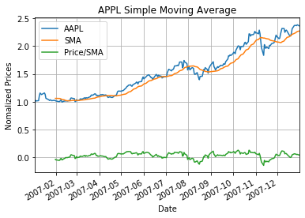

```python
dfsma = get_sma_indicator('AAPL', pricesnormed)
dfsma.plot(grid=True, title='APPL Simple Moving Average', use_index=True)
plt.ylabel('Nomalized Prices')
plt.xlabel('Date')
plt.show()
```

##### 2.1.2 Bollinger Bands

This indicator expands on the Simple Moving Average (SMA) by including standard deviation of prices from the SMA. Bollinger Bands detects the volatility and dynamics of the price movement in the stock price. Using Bollinger Bands, we can predict whether current trend in the stock price will continue or turn around.

Central line in the Bollinger bands represents the Simple Moving Average (SMA). Upper and lower lines of band represent the + and - 2 standard deviations of stock price from the SMA respectively.  
When stock price fluctuates highly, gap between upper and lower bands is largest. Gap is lowest when prices fluctuation is less. If the price is close to or outside of the upper band, the stock price would be considered high and investor should sell the stock. On the other hand, if the price is near the lower band, stock price would be considered low and investor should buy the stock.

Bollinger Band Percentage (%B) is calculated by subtracting the lower band from the price and then dividing it by the difference between upper and lower bands. This BBP is thus less than zero when the price falls below the lower band and is greater than 1 when the price rises above the upper band. The Bollinger Band family is plotted on the same stock data.

- *Middle Band = SMA with look back window of 20 days*
- *Upper Band = SMA + (2 x standard deviation of price)*
- *Lower Band = SMA - (2 x standard deviation of price)*
- *%B = (Current Price - Lower Band) / (Upper Band - Lower Band)*

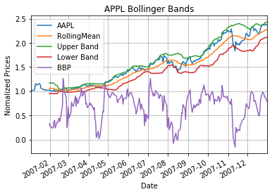

```python
dfbb = get_bollinger_bands('AAPL', pricesnormed)
dfbb.plot(grid=True, title='APPL Bollinger Bands', use_index=True)
plt.ylabel('Nomalized Prices')
plt.xlabel('Date')
plt.show()
```

##### 2.1.3 Momentum

*M = CP – CPn*

Where M is momentum, CP is closing price and n is lookback window. If the current price is higher than the price in the past, then the Momentum is positive. On the other hand, if the current price is lower than the price in the past, then the Momentum is negative. When the Momentum crosses above the zero-line stock price is reversing and price is bottomed out hence it is a buy signal. When the Momentum crosses below the zero-line stock price is reversing and price is topped out hence it is a sell signal.

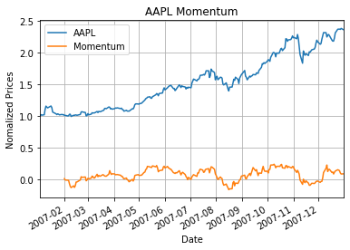

```python
dfmomentum = get_momentum('AAPL', pricesnormed)
dfmomentum.plot(grid=True, title='AAPL Momentum', use_index=True)
plt.ylabel('Nomalized Prices')
plt.xlabel('Date')
plt.show()
```

#### 2.2 Benchmark Statistics

This section caluates the branchmark statistics for the portfolio which will be used in future to compare perfromance of manual and machine learning strategy.

```python
df_benchmark_trades = create_df_benchmark('AAPL', startdt, enddt, 1000)

benchmarkportval = compute_portvals_single_symbol(df_benchmark_trades,'AAPL', start_val=startval,commission=commission,impact=impact)
normedbenchmarkportval = benchmarkportval/benchmarkportval.ix[0]

cr = normedbenchmarkportval.iloc[-1, 0]/normedbenchmarkportval.iloc[0, 0] - 1
daily_returns = compute_daily_returns(normedbenchmarkportval)[1:]
adr = normedbenchmarkportval.iloc[:, 0].mean()
sddr = normedbenchmarkportval.iloc[:, 0].std()
sr = compute_sharpe_ratio(np.sqrt(252), adr, 0, sddr)

print("Cumulative Return of Benchmark: {}".format(cr))
print("Standard Deviation of Benchmark: {}".format(sddr))
print("Average Daily Return of Benchmark: {}".format(adr))
print("Sharpe Ratio of Benchmark: {}".format(sr))
```

```
Cumulative Return of Benchmark: 0.14816715171976713
Standard Deviation of Benchmark: 0.04611657979489601
Average Daily Return of Benchmark: 1.058199249551012
Sharpe Ratio of Benchmark: 364.25928344890207
```

#### 2.3 Theoretically Optimal Strategy

Assuming we can peek into future but constrained by the portfolio size and order limits we create a set of trades that represents the best a strategy could possibly do during the in sample period. Objective is to identify the upper bound on performance. We will use adjusted close prices with the market simulator.

```python
#Calulate Theoratically Optimal Portfolio
trades = []
holdlimit = 0
for i in range(len(prices)-1):
    # print(holdlimit)
    if prices.ix[i,'AAPL'] < prices.ix[i + 1,'AAPL']:
        if holdlimit == 0:
            holdlimit += 1000
            trades.append([prices.index[i], +1000])
        elif holdlimit == 1000:
            trades.append([prices.index[i], 0])
        else:
            holdlimit += 2000
            trades.append([prices.index[i], +2000])
    elif prices.ix[i,'AAPL'] > prices.ix[i + 1,'AAPL']:
        if holdlimit == 0:
            holdlimit -= 1000
            trades.append([prices.index[i], -1000])
        elif holdlimit == -1000:
            trades.append([prices.index[i], 0])
        else:
            holdlimit -= 2000
            trades.append([prices.index[i], -2000])
    else:
        trades.append([prices.index[i], 0])

df_trades = pd.DataFrame(trades, columns=["Date", "Shares"])
df_trades.set_index('Date',inplace=True)


# Get Optimal Portfolio
optimalportval = compute_portvals_single_symbol(df_trades,'AAPL', start_val=startval,commission=commission,impact=impact)
normedoptimalportval = optimalportval/optimalportval.ix[0]
cr = normedoptimalportval.iloc[-1, 0]/normedoptimalportval.iloc[0, 0] - 1
daily_returns = compute_daily_returns(normedoptimalportval)[1:]
adr = normedoptimalportval.iloc[:, 0].mean()
sddr = normedoptimalportval.iloc[:, 0].std()
sr = compute_sharpe_ratio(np.sqrt(252), adr, 0, sddr)

print("Cumulative Return of Optimal Portfolio: {}".format(cr))
print("Standard Deviation of Optimal Portfolio: {}".format(sddr))
print("Average Daily Return of Optimal Portfolio: {}".format(adr))
print("Sharpe Ratio of Benchmark: {}".format(sr))
```

```
Cumulative Return of Optimal Portfolio: 0.5273729276468424
Standard Deviation of Optimal Portfolio: 0.15946987073726213
Average Daily Return of Optimal Portfolio: 1.1954111437226307
Sharpe Ratio of Benchmark: 118.99779887485744
```

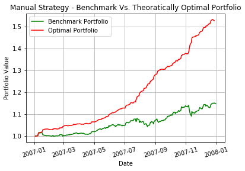

```python
# Plot Benchmark Vs. Theoratically Optimal Portfolio
plt.plot(normedbenchmarkportval, color='green', label='Benchmark Portfolio')
plt.plot(normedoptimalportval, color='red', label='Optimal Portfolio')

plt.title('Manual Strategy - Benchmark Vs. Theoratically Optimal Portfolio')
plt.ylabel('Portfolio Value')
plt.xlabel('Date')
plt.xticks(rotation=15)
plt.grid(True)
plt.legend()
plt.show()
```

**Analysis:** In order to understand upper bounds of performance a theoretically optimal strategy is developed by peaking into future on the in-sample data. To generate optimal trades, a logic was developed looking at next day’s stock price. If the difference between today’s price and tomorrow’s price is positive i.e. today’s price is greater than tomorrow’s price, then stock is sold. On the other hand, if the difference between today’s price and tomorrow’s price is negative i.e. today’s price is less than tomorrow’s price then stock is bought. Strategy was constrained by allowable positions of 1000 shares long, 1000 shares short and 0 shares, hence trading quantity was limited to 2000 shares. A logic was expanded to calculate quantity of shares to be traded based up the current holding quantity of the stock.

Above graph represents the implementation of theoretically optimal strategy for APPL for in sample dataset. As it can be observed from the chart and statistics, theoretically optimal strategy performs very well as compared to benchmark.

#### 2.4 Manual Rule-Based Trader

This section implements a set of rules using the indicators discussed above and devise simple logic using indicators to enter and exit positions in the stock. This strategy leverages the technical indicators to generate trades. Following logic was developed to generate buy, sell or do nothing signals. Buy or sell is triggered when all three indicators meets the thresholds.

- Buy stock if momentum is less than 0.05 and Bollinger’s Band percentage is less than 0.5 and price to SMA ratio is less than 0.1.
- Sell the stock if momentum is greater than 0.05 and Bollinger’s Band percentage is greater than 0.5 and price to SMA ratio is greater than 0.1.  
  Note that Buy, Sell or Do Nothing decision was also constrained by allowable positions of 1000 shares long, 1000 shares short and 0 shares, hence trading quantity was limited to 2000 shares. A logic was expanded to calculate quantity of shares to be traded based up the current holding quantity of the stock.

```python
manstratport = pd.DataFrame(0, index = pricesnormed.index, columns = ["Shares"])

holdlimit = 0
for i in range(len(pricesnormed)-1):
    sma = dfsma.ix[i, 'SMA']
    pr2sma = dfsma.ix[i, 'Price/SMA']
    bbp = dfbb.ix[i, 'BBP']
    momentum = dfmomentum.ix[i, 'Momentum']

    if (momentum < 0.05) and (bbp < 0.5) and (pr2sma<0.1):
        if holdlimit == 0:
            holdlimit += 1000
            manstratport.ix[i,'Shares'] = +1000
        elif holdlimit == 1000:
            manstratport.ix[i,'Shares'] = 0
        else:
            holdlimit += 2000
            manstratport.ix[i,'Shares'] = +2000
    elif (momentum > 0.05) and (bbp > 0.5) and (pr2sma>0.1):
        if holdlimit == 0:
            holdlimit -= 1000
            manstratport.ix[i,'Shares'] = -1000
        elif holdlimit == -1000:
            manstratport.ix[i,'Shares'] = 0
        else:
            holdlimit -= 2000
            manstratport.ix[i,'Shares'] = -2000
    else:
        manstratport.ix[i,'Shares'] = 0

manstratportval = compute_portvals_single_symbol(manstratport,'AAPL', start_val=startval,commission=commission,impact=impact)
normedmanstratportval = manstratportval/manstratportval.ix[0]

cr = normedmanstratportval.iloc[-1, 0]/normedmanstratportval.iloc[0, 0] - 1
daily_returns = compute_daily_returns(normedmanstratportval)[1:]
adr = normedmanstratportval.iloc[:, 0].mean()
sddr = normedmanstratportval.iloc[:, 0].std()
sr = compute_sharpe_ratio(np.sqrt(252), adr, 0, sddr)

print("Cumulative Return of Manual Rule-Based Learner (in-sample): {}".format(cr))
print
print("Standard Deviation of Manual Rule-Based Learner (in-sample): {}".format(sddr))
print
print("Average Daily Return of Manual Rule-Based Learner (in-sample): {}".format(adr))
print
```

```
Cumulative Return of Manual Rule-Based Learner (in-sample): 0.053887414700000136
Standard Deviation of Manual Rule-Based Learner (in-sample): 0.020574654585887562
Average Daily Return of Manual Rule-Based Learner (in-sample): 1.0224810748992028
```

```
<function print>
```

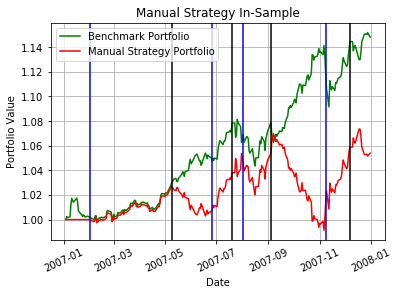

```python
# In Sample
plt.figure(0)
plt.plot(normedbenchmarkportval, color='green', label='Benchmark Portfolio')
plt.plot(normedmanstratportval, color='red', label='Manual Strategy Portfolio')
for i, row in manstratport.iterrows():
    if manstratport.ix[i,"Shares"] < 0:
        plt.axvline(x=i, color='black')
    elif manstratport.ix[i,"Shares"] > 0:
        plt.axvline(x=i, color='blue')

plt.title('Manual Strategy In-Sample')
plt.ylabel('Portfolio Value')
plt.xlabel('Date')
plt.xticks(rotation=25)
plt.grid(True)
plt.legend()
plt.show()
```

#### 2.5 Q Learning Agent

Agent starts with an empty Q table, mapping states to values of actions. Q Learning agents has 3 actions viz, Buy, Sell or Do Nothing. Agent interacts with the environment, updates the Q Table with the tuple containing state, action, reward, new state. After that the agent decides which action to take.

```
1 -0.20088455931322458
2 -0.16377418712142955
3 -0.08312472420346406
4 -0.057257355208542804
5 -0.021517086494171944
6 -0.013458663769868373
7 -0.013458663769868373
8 -0.013074995115529786
9 -0.013074995115529786
10 -0.013074995115529786
11 -0.013074995115529786
12 -0.013074995115529786
13 -0.013074995115529786
14 -0.013074995115529786
15 -0.013074995115529786
16 -0.013074995115529786
17 -0.013074995115529786
18 -0.013074995115529786
19 -0.013074995115529786
20 -0.013074995115529786
21 -0.013074995115529786
```

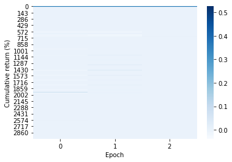

```
Cumulative Return of Q Learner (in-sample): -0.013074995115529786
Standard Deviation of Q Learner (in-sample): 0.007829242688226754
Average Daily Return of Q Learner (in-sample): 0.9911810593259099
```

```
<function print>
```

```python
learner = QLearner(num_states=3000, num_actions=3)
stl = StrategyLearner(num_shares=1000, impact=impact,
                      commission=commission, verbose=True,
                      learner=learner)
stl.add_evidence(symbol="AAPL", start_val=startval,
                 start_date=startdt, end_date=enddt)
df_trades = stl.test_policy(symbol='AAPL',
                            start_date=startdt, end_date=enddt)

stratlernportval = compute_portvals_single_symbol(df_trades,'AAPL', start_val=startval,commission=commission,impact=impact)
normedstratlernportval = stratlernportval/stratlernportval.ix[0]

cr = normedstratlernportval.iloc[-1, 0]/normedstratlernportval.iloc[0, 0] - 1
daily_returns = compute_daily_returns(normedstratlernportval)[1:]
adr = normedstratlernportval.iloc[:, 0].mean()
sddr = normedstratlernportval.iloc[:, 0].std()
sr = compute_sharpe_ratio(np.sqrt(252), adr, 0, sddr)

print("Cumulative Return of Q Learner (in-sample): {}".format(cr))
print
print("Standard Deviation of Q Learner (in-sample): {}".format(sddr))
print
print("Average Daily Return of Q Learner (in-sample): {}".format(adr))
print
```

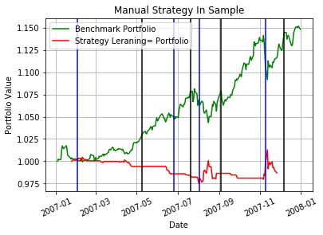

```python
# In Sample
plt.figure(0)
plt.plot(normedbenchmarkportval, color='green', label='Benchmark Portfolio')
plt.plot(normedstratlernportval, color='red', label='Strategy Leraning= Portfolio')
for i, row in manstratport.iterrows():
    if manstratport.ix[i,"Shares"] < 0:
        plt.axvline(x=i, color='black')
    elif manstratport.ix[i,"Shares"] > 0:
        plt.axvline(x=i, color='blue')

plt.title('Manual Strategy In Sample')
plt.ylabel('Portfolio Value')
plt.xlabel('Date')
plt.xticks(rotation=25)
plt.grid(True)
plt.legend()
plt.show()
```

#### 2.6 Out-Samples - Manual Rule Based Learner vs. Benchmark Statistics

```python
# Out Sample Charts
startdt = dt.datetime(2008,1,1)
enddt = dt.datetime(2008,12,31)
symbols = ['AAPL']
startval = 100000
commission = 9.95
impact = 0.005

# Get Portfolio Benchmark
dates = pd.date_range(startdt, enddt)
prices = get_data(symbols, dates)
prices = prices.fillna(method="ffill")
prices = prices.fillna(method="bfill")
prices = prices.drop(['SPY'], axis=1)
pricesnormed = prices/prices.ix[0,]

df_benchmark_trades = create_df_benchmark('AAPL', startdt, enddt, 1000)
benchmarkportval = compute_portvals_single_symbol(df_benchmark_trades,'AAPL', start_val=startval,commission=commission,impact=impact)
normedbenchmarkportval = benchmarkportval/benchmarkportval.ix[0]

dfsma = get_sma_indicator('AAPL', pricesnormed)
dfbb = get_bollinger_bands('AAPL', pricesnormed)
dfmomentum = get_momentum('AAPL', pricesnormed)

manstratport = pd.DataFrame(0, index = pricesnormed.index, columns = ["Shares"])

holdlimit = 0
for i in range(len(pricesnormed)-1):
    sma = dfsma.ix[i, 'SMA']
    pr2sma = dfsma.ix[i, 'Price/SMA']
    bbp = dfbb.ix[i, 'BBP']
    momentum = dfmomentum.ix[i, 'Momentum']

    if (momentum < 0.05) and (bbp < 0.5) and (pr2sma<0.1):
        if holdlimit == 0:
            holdlimit += 1000
            manstratport.ix[i,'Shares'] = +1000
        elif holdlimit == 1000:
            manstratport.ix[i,'Shares'] = 0
        else:
            holdlimit += 2000
            manstratport.ix[i,'Shares'] = +2000
    elif (momentum > 0.05) and (bbp > 0.5) and (pr2sma>0.1):
        if holdlimit == 0:
            holdlimit -= 1000
            manstratport.ix[i,'Shares'] = -1000
        elif holdlimit == -1000:
            manstratport.ix[i,'Shares'] = 0
        else:
            holdlimit -= 2000
            manstratport.ix[i,'Shares'] = -2000
    else:
        manstratport.ix[i,'Shares'] = 0

manstratportval = compute_portvals_single_symbol(manstratport,'AAPL', start_val=startval,commission=commission,impact=impact)
normedmanstratportval = manstratportval/manstratportval.ix[0]

cr = normedmanstratportval.iloc[-1, 0]/normedmanstratportval.iloc[0, 0] - 1
daily_returns = compute_daily_returns(normedmanstratportval)[1:]
adr = normedmanstratportval.iloc[:, 0].mean()
sddr = normedmanstratportval.iloc[:, 0].std()
sr = compute_sharpe_ratio(np.sqrt(252), adr, 0, sddr)

print("Cumulative Return of Manual Rule-Based Learner (out-sample): {}".format(cr))
print
print("Standard Deviation of Manual Rule-Based Learner (out-sample): {}".format(sddr))
print
print("Average Daily Return of Manual Rule-Based Learner (out-sample): {}".format(adr))
print
```

```
Cumulative Return of Manual Rule-Based Learner (out-sample): -0.13833036045000002
Standard Deviation of Manual Rule-Based Learner (out-sample): 0.05055180127458431
Average Daily Return of Manual Rule-Based Learner (out-sample): 0.9352028156689723
```

```
<function print>
```

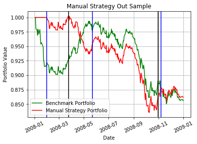

```python
plt.plot(normedbenchmarkportval, color='green', label='Benchmark Portfolio')
plt.plot(normedmanstratportval, color='red', label='Manual Strategy Portfolio')
for i, row in manstratport.iterrows():
    if manstratport.ix[i,"Shares"] < 0:
        plt.axvline(x=i, color='black')
    elif manstratport.ix[i,"Shares"] > 0:
        plt.axvline(x=i, color='blue')
plt.title('Manual Strategy Out Sample')
plt.ylabel('Portfolio Value')
plt.xlabel('Date')
plt.xticks(rotation=25)
plt.grid(True)
plt.legend()
plt.show()
```

#### 2.7 Out-Samples - Q Learner vs. Benchmark Statistics

```python
df_trades = stl.test_policy(symbol='AAPL', start_date=startdt, end_date=enddt)

stratlernportval = compute_portvals_single_symbol(df_trades,'AAPL', start_val=startval,commission=commission,impact=impact)
normedstratlernportval = stratlernportval/stratlernportval.ix[0]

cr = normedstratlernportval.iloc[-1, 0]/normedstratlernportval.iloc[0, 0] - 1
daily_returns = compute_daily_returns(normedstratlernportval)[1:]
adr = normedstratlernportval.iloc[:, 0].mean()
sddr = normedstratlernportval.iloc[:, 0].std()
sr = compute_sharpe_ratio(np.sqrt(252), adr, 0, sddr)

print("Cumulative Return of Q Learner (out-sample): {}".format(cr))
print
print("Standard Deviation of Q Learner (out-sample): {}".format(sddr))
print
print("Average Daily Return of Q Learner (out-sample): {}".format(adr))
print
```

```
Cumulative Return of Q Learner (out-sample): 0.04332619384127234
Standard Deviation of Q Learner (out-sample): 0.028013507291850863
Average Daily Return of Q Learner (out-sample): 1.0215811436030229
```

```
<function print>
```

[figure not shown]

```python
# In Sample
plt.figure(0)
plt.plot(normedbenchmarkportval, color='green', label='Benchmark Portfolio')
plt.plot(normedstratlernportval, color='red', label='Strategy Leraning= Portfolio')
for i, row in manstratport.iterrows():
    if manstratport.ix[i,"Shares"] < 0:
        plt.axvline(x=i, color='black')
    elif manstratport.ix[i,"Shares"] > 0:
        plt.axvline(x=i, color='blue')

plt.title('Manual Strategy In Sample')
plt.ylabel('Portfolio Value')
plt.xlabel('Date')
plt.xticks(rotation=25)
plt.grid(True)
plt.legend()
plt.show()
```

**Citiation:** Market Simulator code and Utility functions are adapted from code available publicly at below location. https://resources.oreilly.com/binderhub/reinforcement-learning-building-recommender-systems/blob/master/notebooks/marketsim.py